# The Effect of Temperature on Houston’s Monthly Gas and Electricity Consumption in 2024

# Introduction

Houston, as one of the largest cities in the United States, experiences significant seasonal variations in weather conditions throughout the year. These temperature fluctuations directly impact residential and commercial energy consumption, particularly for heating and cooling. Understanding the relationship between temperature variations and energy usage is crucial for energy planning, forecasting demand, and identifying efficiency opportunities.

This project investigates **how temperature influences Houston’s monthly energy consumption patterns in 2024**. We examine two primary energy sources:

1. **Electricity (kWh)** - used primarily for air conditioning and appliances
2. **Natural Gas (MCF)** - used primarily for heating and water heating

The analysis uses weather data from the National Oceanic and Atmospheric Administration (NOAA) and actual energy consumption data from Houston utility records for the entire year 2024. Our research questions are:

- Does higher temperature correlate with higher electricity consumption?
- Does lower temperature correlate with higher gas consumption?
- Can we build predictive models for energy usage based on temperature alone?
- Are there seasonal patterns in the temperature-energy relationship?

# Data

## Data Sources

**1. Weather Data (NOAA)**

Daily weather data for Houston in 2024 was obtained from NOAA’s National Centers for Environmental Information (NCEI). The data comes from the Houston National Weather Service Office station (ID: USC00414333, located at the Houston Intercontinental Airport). Daily measurements include: - Daily maximum temperature (°F) - Daily minimum temperature (°F)  
- Daily average temperature (°F) - Daily precipitation (inches)

These daily values were aggregated to monthly averages to align with energy consumption reporting periods.

**2. Electricity Consumption Data**

Hourly electricity consumption data for Houston in 2024 was obtained from the Houston utility district. This data includes: - Timestamp (hour and date) - Hourly ambient temperature (°F) measured at the weather station - Hourly electricity consumption (kWh)

These hourly readings were aggregated to monthly totals (sum of all hours in each month).

**3. Natural Gas Consumption Data**

Monthly natural gas consumption for Houston in 2024 was collected from utility billing records. Gas consumption is reported in MCF (thousands of cubic feet), which is the standard measurement unit for natural gas in the United States.

## Data Preparation

Below is the code to load and prepare all three datasets for analysis:

```r
# Load required libraries
library(tidyverse)
library(ggplot2)
library(readr)
library(knitr)

# Load the merged dataset containing all variables
energy_weather <- read_csv('houston_energy_weather_2024.csv')

# Display the complete dataset
head(energy_weather, 12)
```

```
## # A tibble: 12 × 6
##    month date       mean_temperature_f total_electricity_kwh total_gas_mcf
##    <dbl> <date>                  <dbl>                 <dbl>         <dbl>
##  1     1 2024-01-01               54.8                 1047.         12
##  2     2 2024-02-01               55.2                  960.          8.19
##  3     3 2024-03-01               63.0                  800.         11.9
##  4     4 2024-04-01               69.9                  736.          3.63
##  5     5 2024-05-01               78.0                  989.          5.48
##  6     6 2024-06-01               83.9                 1204.          1.67
##  7     7 2024-07-01               86.9                 1378.          1.35
##  8     8 2024-08-01               83.2                 1206.          1.61
##  9     9 2024-09-01               78.6                  981.          5.51
## 10    10 2024-10-01               69.0                  749.          3.62
## 11    11 2024-11-01               61.3                  834.          3.31
## 12    12 2024-12-01               55.3                 1033.         10.7
## # ℹ 1 more variable: total_precipitation_in <dbl>
```

**Why this approach?** We use a merged dataset to ensure all observations (months) have matching temperature, electricity, and gas values. The monthly aggregation is appropriate because energy billing is done monthly, and monthly averages smooth out day-to-day weather noise while preserving seasonal patterns.

```r
# Examine the structure and summary of the data
str(energy_weather)
```

```
## spc_tbl_ [12 × 6] (S3: spec_tbl_df/tbl_df/tbl/data.frame)
##  $ month                 : num [1:12] 1 2 3 4 5 6 7 8 9 10 ...
##  $ date                  : Date[1:12], format: "2024-01-01" "2024-02-01" ...
##  $ mean_temperature_f    : num [1:12] 54.8 55.2 63 69.9 78 ...
##  $ total_electricity_kwh : num [1:12] 1047 960 800 736 989 ...
##  $ total_gas_mcf         : num [1:12] 12 8.19 11.91 3.63 5.48 ...
##  $ total_precipitation_in: num [1:12] 1.27 1.54 0.89 2.08 3.09 1.94 2.27 1.19 2.05 1.89 ...
##  - attr(*, "spec")=
##   .. cols(
##   ..   month = col_double(),
##   ..   date = col_date(format = ""),
##   ..   mean_temperature_f = col_double(),
##   ..   total_electricity_kwh = col_double(),
##   ..   total_gas_mcf = col_double(),
##   ..   total_precipitation_in = col_double()
##   .. )
##  - attr(*, "problems")=<externalptr>
```

```r
summary(energy_weather)
```

```
##      month            date            mean_temperature_f total_electricity_kwh
##  Min.   : 1.00   Min.   :2024-01-01   Min.   :54.75      Min.   : 736.0
##  1st Qu.: 3.75   1st Qu.:2024-03-24   1st Qu.:59.79      1st Qu.: 825.5
##  Median : 6.50   Median :2024-06-16   Median :69.44      Median : 984.5
##  Mean   : 6.50   Mean   :2024-06-16   Mean   :69.93      Mean   : 992.8
##  3rd Qu.: 9.25   3rd Qu.:2024-09-08   3rd Qu.:79.78      3rd Qu.:1085.8
##  Max.   :12.00   Max.   :2024-12-01   Max.   :86.90      Max.   :1377.9
##  total_gas_mcf    total_precipitation_in
##  Min.   : 1.350   Min.   :0.890
##  1st Qu.: 2.900   1st Qu.:1.345
##  Median : 4.555   Median :1.915
##  Mean   : 5.746   Mean   :1.817
##  3rd Qu.: 8.810   3rd Qu.:2.115
##  Max.   :12.000   Max.   :3.090
```

# Exploring the Data

## Part I: Overall Summary Statistics and Distributions

Let’s start by examining the basic patterns in temperature and energy consumption:

```r
# Create a comprehensive summary table
summary_table <- energy_weather %>%
  select(month, mean_temperature_f, total_electricity_kwh, total_gas_mcf) %>%
  mutate(month_name = month.abb[month]) %>%
  select(month_name, mean_temperature_f, total_electricity_kwh, total_gas_mcf) %>%
  rename("Month" = month_name,
         "Mean Temp (°F)" = mean_temperature_f,
         "Electricity (kWh)" = total_electricity_kwh,
         "Gas (MCF)" = total_gas_mcf)

kable(summary_table, digits = 2, caption = "Monthly Summary: Temperature and Energy Consumption (2024)")
```

Monthly Summary: Temperature and Energy Consumption (2024)

| Month | Mean Temp (°F) | Electricity (kWh) | Gas (MCF) |
| --- | --- | --- | --- |
| Jan | 54.75 | 1046.53 | 12.00 |
| Feb | 55.23 | 959.50 | 8.19 |
| Mar | 62.99 | 799.58 | 11.91 |
| Apr | 69.90 | 736.02 | 3.63 |
| May | 78.05 | 988.51 | 5.48 |
| Jun | 83.94 | 1203.68 | 1.67 |
| Jul | 86.90 | 1377.87 | 1.35 |
| Aug | 83.18 | 1205.53 | 1.61 |
| Sep | 78.64 | 980.57 | 5.51 |
| Oct | 68.98 | 748.87 | 3.62 |
| Nov | 61.30 | 834.15 | 3.31 |
| Dec | 55.27 | 1032.91 | 10.67 |

## Part II: Visualizing Temperature Patterns

Let’s examine how temperature varies across the year:

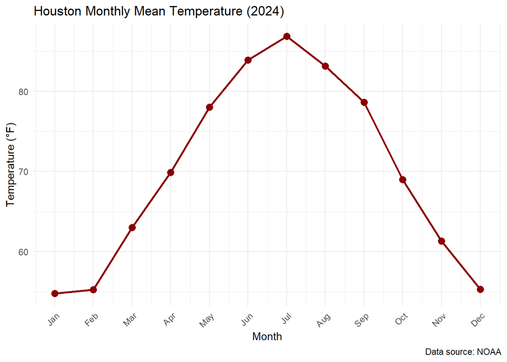

```r
# Plot 1: Monthly Temperature Variation
ggplot(energy_weather, aes(x = month, y = mean_temperature_f)) +
  geom_line(color = "darkred", size = 1) +
  geom_point(color = "darkred", size = 3) +
  labs(title = "Houston Monthly Mean Temperature (2024)",
       x = "Month",
       y = "Temperature (°F)",
       caption = "Data source: NOAA") +
  scale_x_continuous(breaks = 1:12, labels = month.abb) +
  theme_minimal() +
  theme(axis.text.x = element_text(angle = 45, hjust = 1))
```

## Part III: Electricity Consumption Patterns

Now let’s examine how electricity usage changes throughout the year:

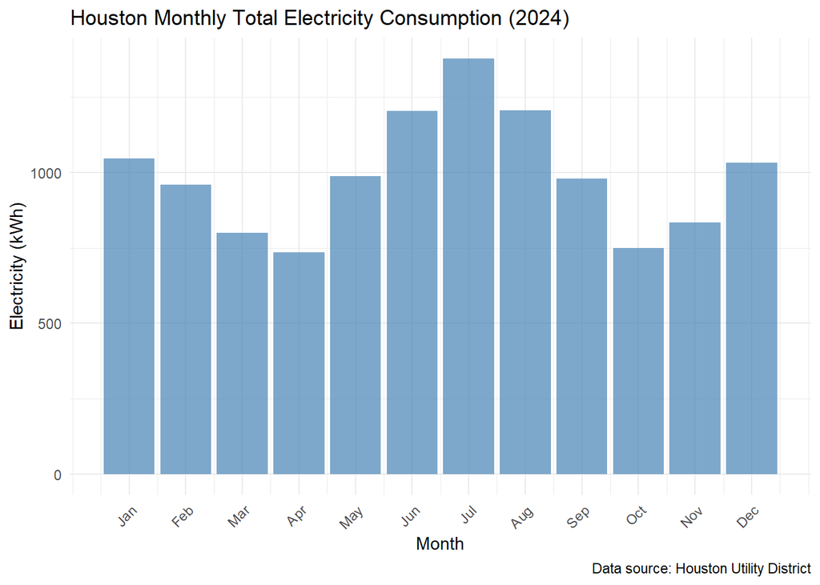

```r
# Plot 2: Monthly Electricity Consumption
ggplot(energy_weather, aes(x = month, y = total_electricity_kwh)) +
  geom_bar(stat = "identity", fill = "steelblue", alpha = 0.7) +
  labs(title = "Houston Monthly Total Electricity Consumption (2024)",
       x = "Month",
       y = "Electricity (kWh)",
       caption = "Data source: Houston Utility District") +
  scale_x_continuous(breaks = 1:12, labels = month.abb) +
  theme_minimal() +
  theme(axis.text.x = element_text(angle = 45, hjust = 1))
```

**Observation:** Electricity consumption shows a **U-shaped summer peak pattern**: - **Low consumption:** April (736 kWh) - mild spring weather - **Peak consumption:** July (1,378 kWh) - extreme heat drives heavy AC usage - **Winter usage:** Higher than spring/fall (1,046 kWh in January), likely due to some heating and baseline appliance use

## Part IV: Gas Consumption Patterns

Let’s examine natural gas usage, which should show the opposite pattern:

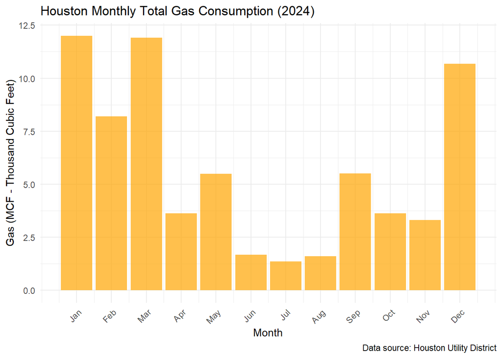

```r
# Plot 3: Monthly Gas Consumption
ggplot(energy_weather, aes(x = month, y = total_gas_mcf)) +
  geom_bar(stat = "identity", fill = "orange", alpha = 0.7) +
  labs(title = "Houston Monthly Total Gas Consumption (2024)",
       x = "Month",
       y = "Gas (MCF - Thousand Cubic Feet)",
       caption = "Data source: Houston Utility District") +
  scale_x_continuous(breaks = 1:12, labels = month.abb) +
  theme_minimal() +
  theme(axis.text.x = element_text(angle = 45, hjust = 1))
```

## Part V: Temperature vs. Energy Consumption Relationships

The key analysis: how do temperature and energy usage relate?

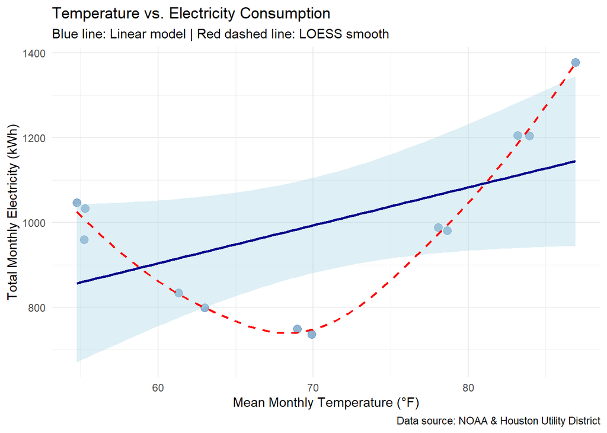

```r
# Plot 4: Temperature vs. Electricity (primary relationship)
ggplot(energy_weather, aes(x = mean_temperature_f, y = total_electricity_kwh)) +
  geom_point(size = 3, color = "steelblue", alpha = 0.6) +
  geom_smooth(method = "lm", se = TRUE, color = "darkblue", fill = "lightblue") +
  geom_smooth(method = "loess", se = FALSE, color = "red", linetype = "dashed", size = 0.8) +
  labs(title = "Temperature vs. Electricity Consumption",
       x = "Mean Monthly Temperature (°F)",
       y = "Total Monthly Electricity (kWh)",
       subtitle = "Blue line: Linear model | Red dashed line: LOESS smooth",
       caption = "Data source: NOAA & Houston Utility District") +
  theme_minimal()
```